# Tipologia Pac 2

Alexandre Fló Cuesta i Arnau Gironella

12/01/2022

## 1. Descripció del dataset.

**Perquè és important i quina pregunta/problema pretén respondre?**

Hem decidit agafar el conjunt de dades de mostra proposat per el professorat ja que és prou interessant i conté tant variables categòriques com numèriques.

La nostra pregunta i/o problema és esbrinar si conjunt de dades serveix per predir de forma efectiva un atac de cor, i en cas que sigui efectiu, volem comprovar si la freqüència cardíaca màxima que pot arribar una persona està relacionada amb el risc coronari.

## 2. Integració i selecció de les dades d’interès a analitzar.

En aquest cas hem decidit mantenir totes les variables fins que poguem analitzar quines són relament significatives per resoldre el problema:

age: L’edat de la persona en anys

sex: El sexe de la persona (1 = home, 0 = dona)

cp: tipus de dolor toràcic

- Valor 0: asimptomàtic
- Valor 1: angina atípica
- Valor 2: dolor no anginós
- Valor 3: angina típica

trtbps: La pressió arterial en repòs de la persona (mm Hg a l’ingrés a l’hospital)

chol: Mesura del colesterol de la persona en mg/dl

fbs: Glucèmia en dejú de la persona (> 120 mg/dl, 1 = veritable; 0 = fals)

restecg: resultats de l’electrocardiograma en repòs:

- Valor 0: hipertròfia ventricular esquerra probable o definida segons els criteris de Estes
- Valor 1: normal
- Valor 2: anomalia de l’ona ST-T (inversió de l’ona T i/o elevació o depressió del ST > 0,05 mV)

thalachh: La freqüència cardíaca màxima aconseguida per la persona

exng: Angina induïda per l’exercici (1 = sí; 0 = no)

oldpeak: Depressió del ST induïda per l’exercici en relació amb el repòs

slp: el pendent del segment ST màxim de l’exercici

- 0: descendent
- 1: pla
- 2: ascendent

thall: Un trastorn sanguini anomenat talasemia

- Valor 1: defecte fix (absència de flux sanguini en alguna part del cor)
- Valor 2: flux sanguini normal
- Valor 3: defecte reversible (s’observa un flux sanguini però no és normal)

output: cardiopatia (1 = no, 0= sí)

## 3. Neteja de les dades

### 3.1. Les dades contenen zeros o elements buits? Gestiona cadascun d’aquests casos.

Primerament carreguem les dades, en aquest cas és “heart.csv” i comprovem si hi ha alguna columna que tingui valors nuls o valors buits.

```r
df <- read.csv("/Users/albert/Desktop/heart.csv")
df2 <- read.csv("/Users/albert/Desktop/heart.csv")

str(df)
```

```
## 'data.frame':    303 obs. of  14 variables:
##  $ age     : int  63 37 41 56 57 57 56 44 52 57 ...
##  $ sex     : int  1 1 0 1 0 1 0 1 1 1 ...
##  $ cp      : int  3 2 1 1 0 0 1 1 2 2 ...
##  $ trtbps  : int  145 130 130 120 120 140 140 120 172 150 ...
##  $ chol    : int  233 250 204 236 354 192 294 263 199 168 ...
##  $ fbs     : int  1 0 0 0 0 0 0 0 1 0 ...
##  $ restecg : int  0 1 0 1 1 1 0 1 1 1 ...
##  $ thalachh: int  150 187 172 178 163 148 153 173 162 174 ...
##  $ exng    : int  0 0 0 0 1 0 0 0 0 0 ...
##  $ oldpeak : num  2.3 3.5 1.4 0.8 0.6 0.4 1.3 0 0.5 1.6 ...
##  $ slp     : int  0 0 2 2 2 1 1 2 2 2 ...
##  $ caa     : int  0 0 0 0 0 0 0 0 0 0 ...
##  $ thall   : int  1 2 2 2 2 1 2 3 3 2 ...
##  $ output  : int  1 1 1 1 1 1 1 1 1 1 ...
```

```r
colSums(is.na(df))
```

```
##      age      sex       cp   trtbps     chol      fbs  restecg thalachh
##        0        0        0        0        0        0        0        0
##     exng  oldpeak      slp      caa    thall   output
##        0        0        0        0        0        0
```

```r
colSums(df == "")
```

```
##      age      sex       cp   trtbps     chol      fbs  restecg thalachh
##        0        0        0        0        0        0        0        0
##     exng  oldpeak      slp      caa    thall   output
##        0        0        0        0        0        0
```

Posteriorment transformem algunes de les dades categòriques a factor.

```r
df$sex <- factor(df$sex)
df$exng <- factor(df$exng)
df$cp <- factor(df$cp)
df$fbs <- factor(df$fbs)
df$restecg <- factor(df$restecg)
df$output <- factor(df$output)
levels(df$output)=c("Yes","No")

str(df)
```

```
## 'data.frame':    303 obs. of  14 variables:
##  $ age     : int  63 37 41 56 57 57 56 44 52 57 ...
##  $ sex     : Factor w/ 2 levels "0","1": 2 2 1 2 1 2 1 2 2 2 ...
##  $ cp      : Factor w/ 4 levels "0","1","2","3": 4 3 2 2 1 1 2 2 3 3 ...
##  $ trtbps  : int  145 130 130 120 120 140 140 120 172 150 ...
##  $ chol    : int  233 250 204 236 354 192 294 263 199 168 ...
##  $ fbs     : Factor w/ 2 levels "0","1": 2 1 1 1 1 1 1 1 2 1 ...
##  $ restecg : Factor w/ 3 levels "0","1","2": 1 2 1 2 2 2 1 2 2 2 ...
##  $ thalachh: int  150 187 172 178 163 148 153 173 162 174 ...
##  $ exng    : Factor w/ 2 levels "0","1": 1 1 1 1 2 1 1 1 1 1 ...
##  $ oldpeak : num  2.3 3.5 1.4 0.8 0.6 0.4 1.3 0 0.5 1.6 ...
##  $ slp     : int  0 0 2 2 2 1 1 2 2 2 ...
##  $ caa     : int  0 0 0 0 0 0 0 0 0 0 ...
##  $ thall   : int  1 2 2 2 2 1 2 3 3 2 ...
##  $ output  : Factor w/ 2 levels "Yes","No": 2 2 2 2 2 2 2 2 2 2 ...
```

### 3.2. Identifica i gestiona els valors extrems.

Amb la funció de boxplot de R podem veure fàcilment quins son els valors atípics de cadascuna de les variables.

```r
# crear lista con nombres de las variables
var_names <- names(df)[1:14]

var_names
```

```
##  [1] "age"      "sex"      "cp"       "trtbps"   "chol"     "fbs"
##  [7] "restecg"  "thalachh" "exng"     "oldpeak"  "slp"      "caa"
## [13] "thall"    "output"
```

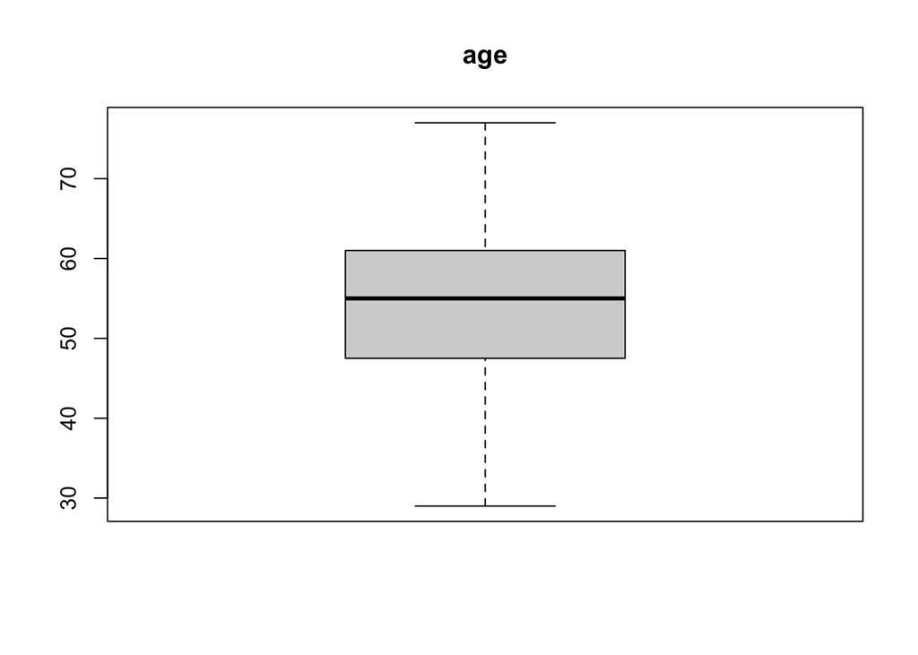

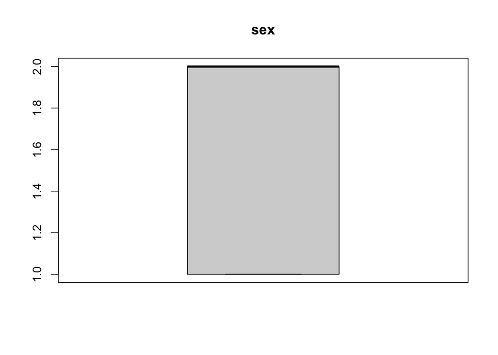

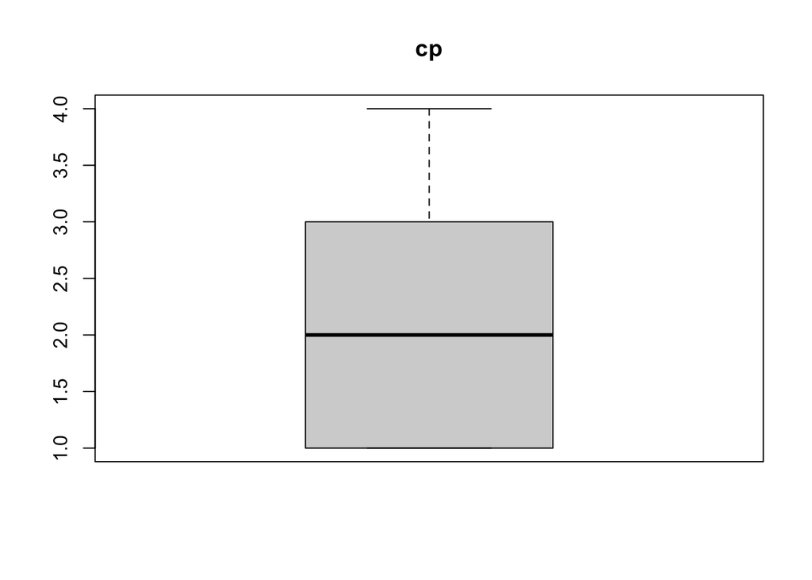

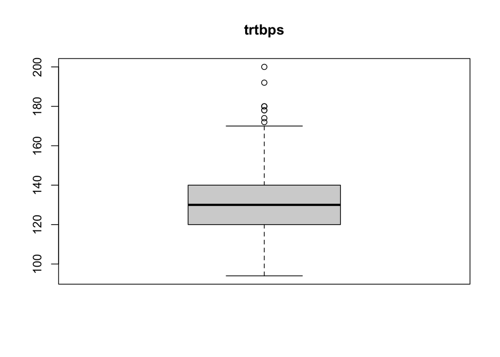

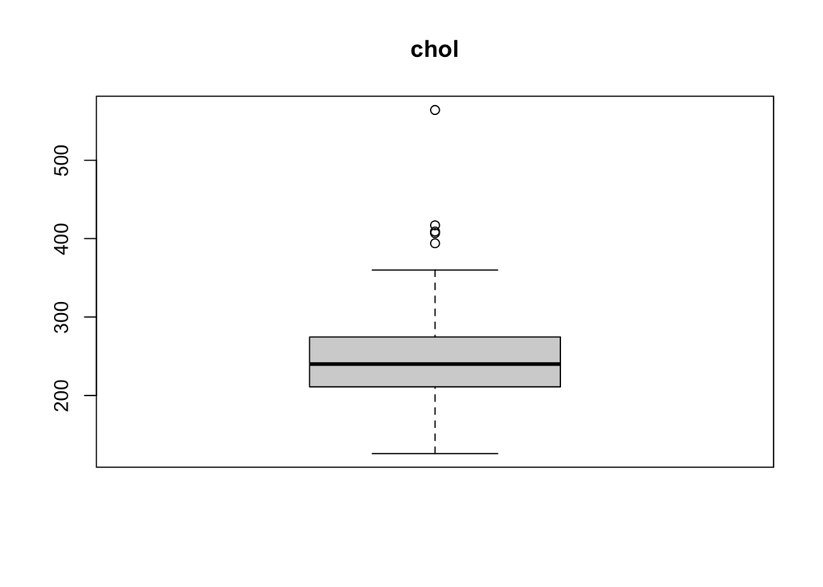

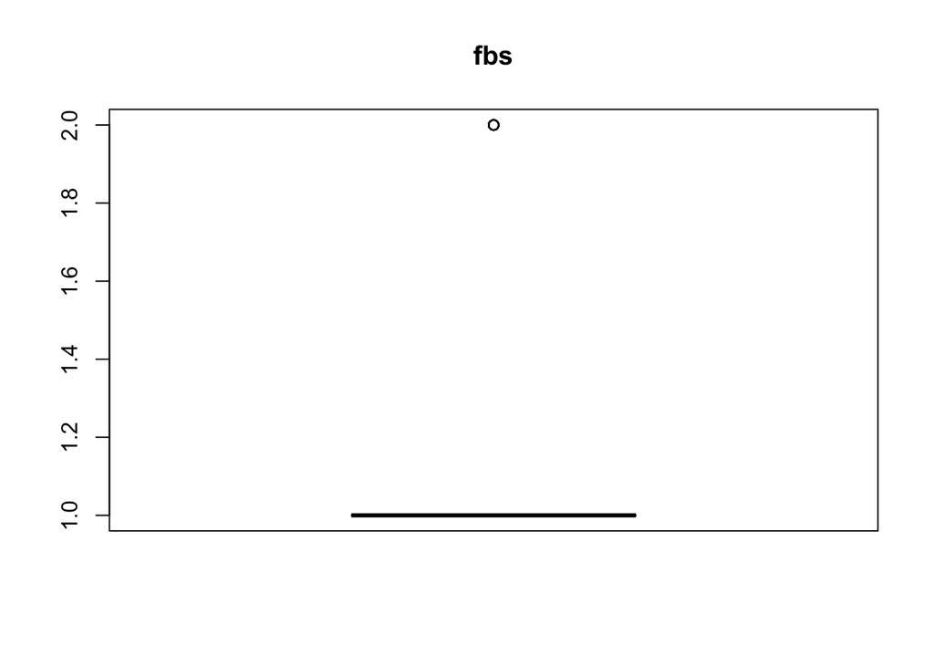

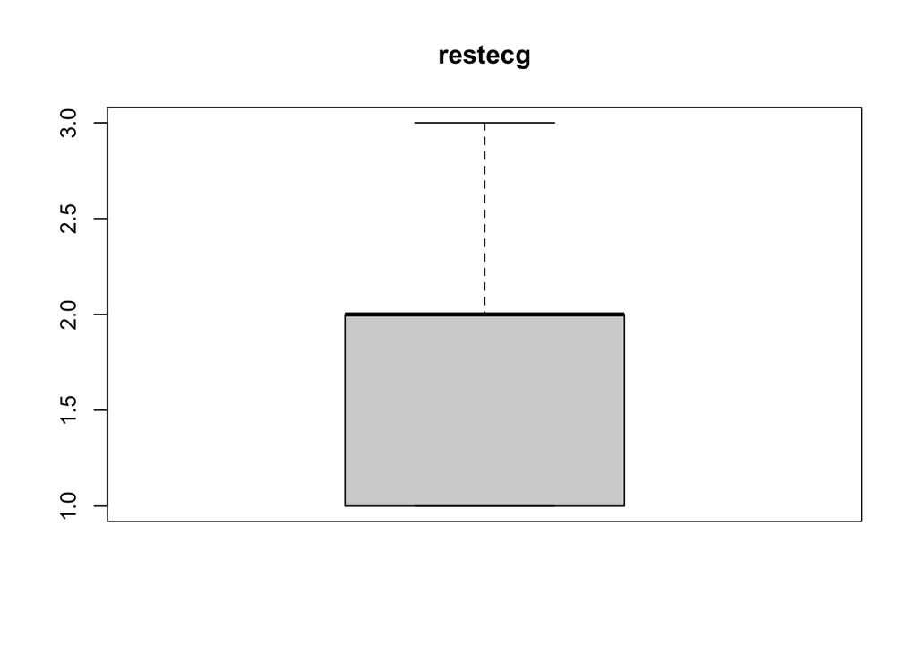

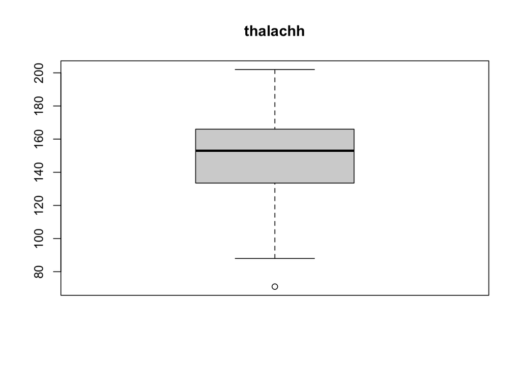

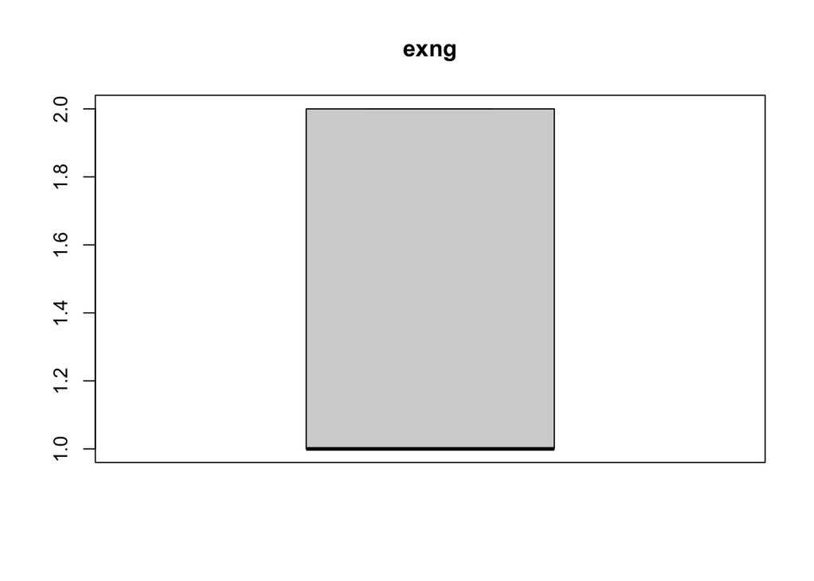

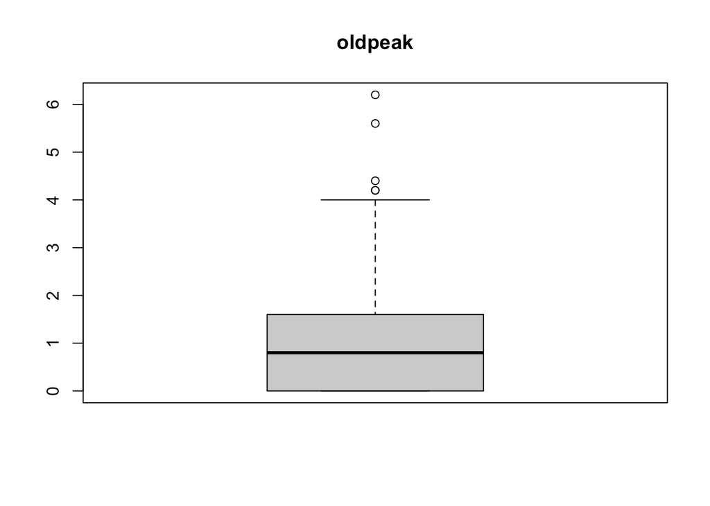

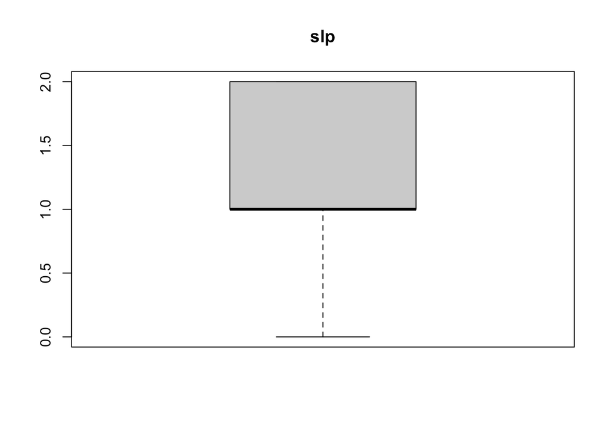

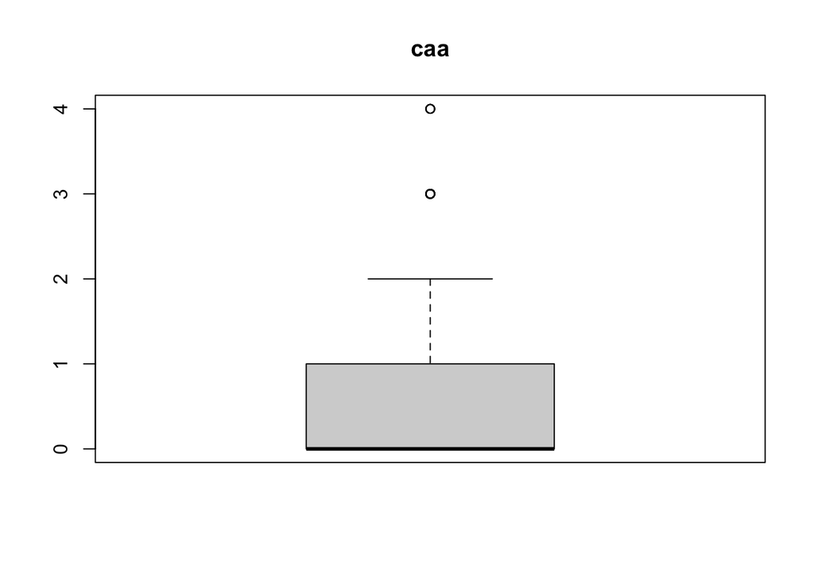

[2 more figures not shown]

```r
# loop para graficar boxplots de cada variable
for (i in var_names) {
  boxplot((df[[i]]), main = i)
}
```

## 4. Anàlisi de les dades.

### 4.2. Comprovació de la normalitat i homogeneïtat de la variància.

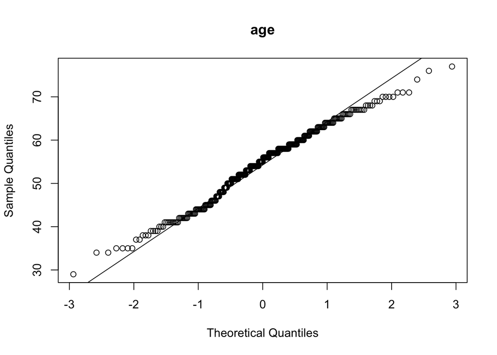

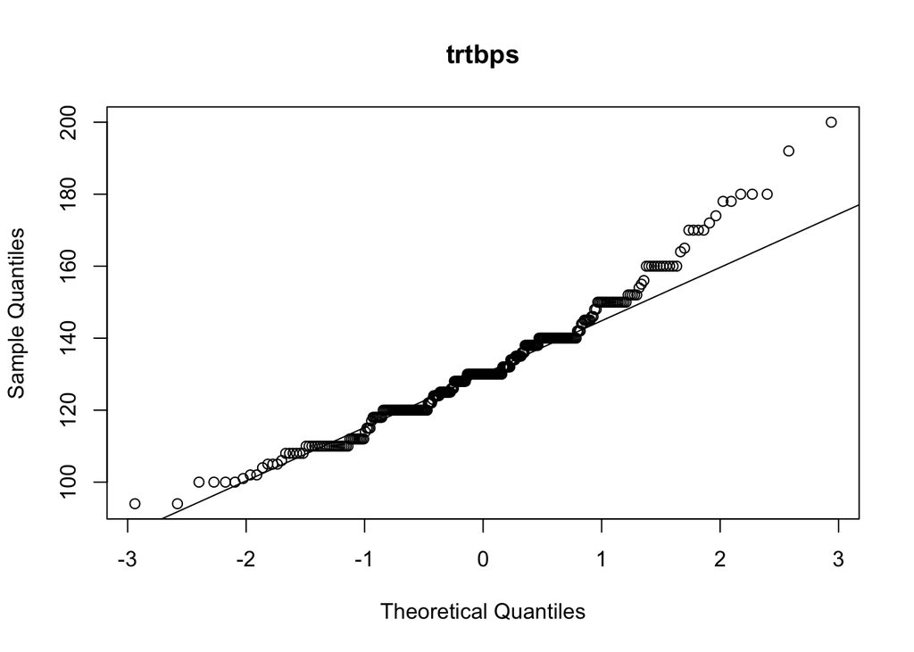

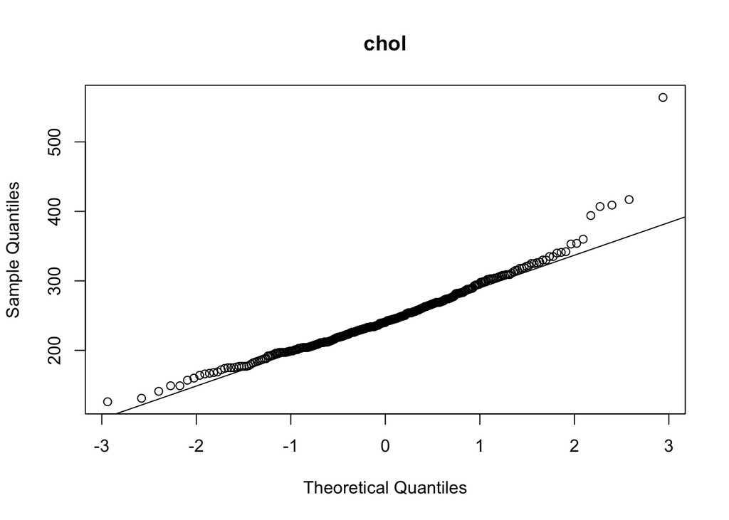

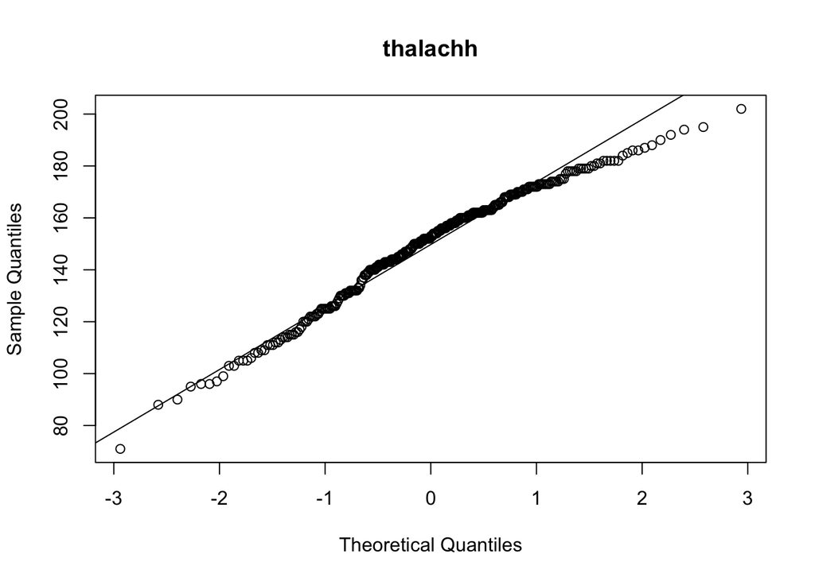

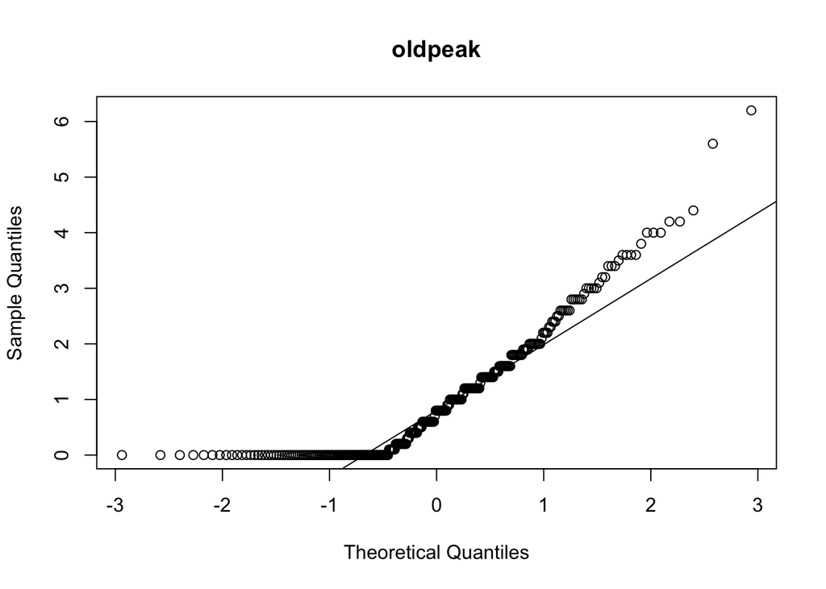

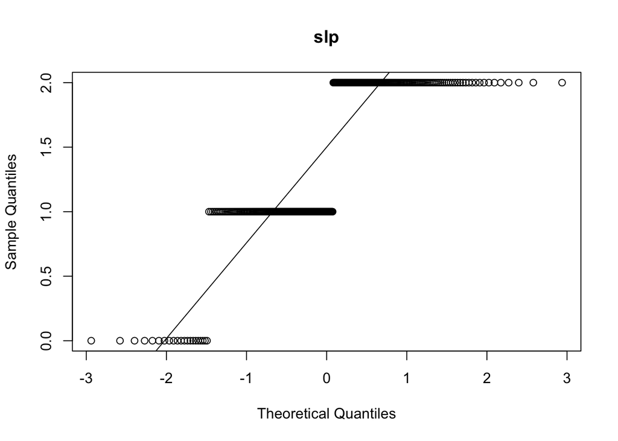

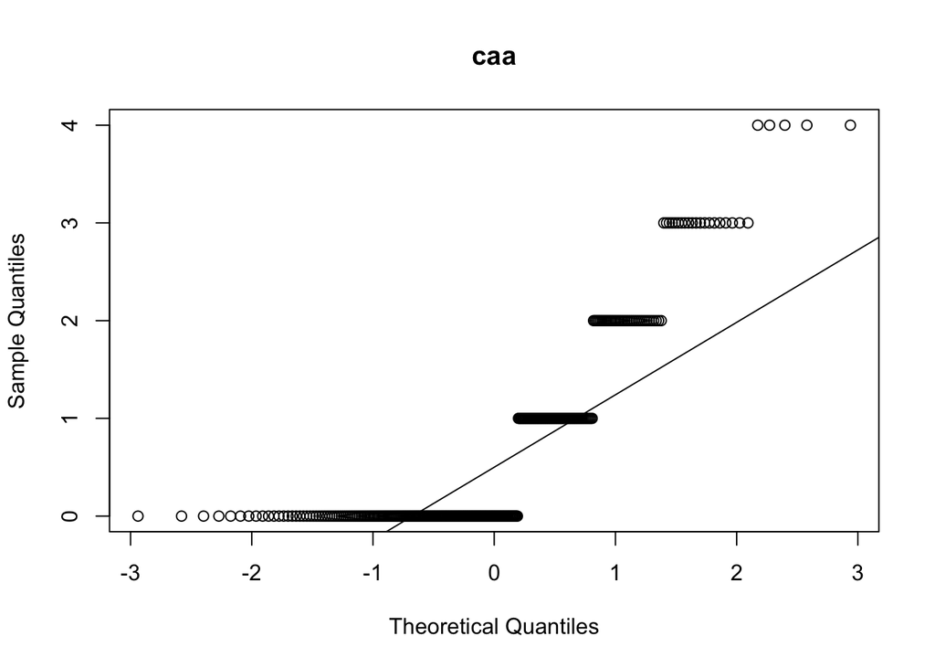

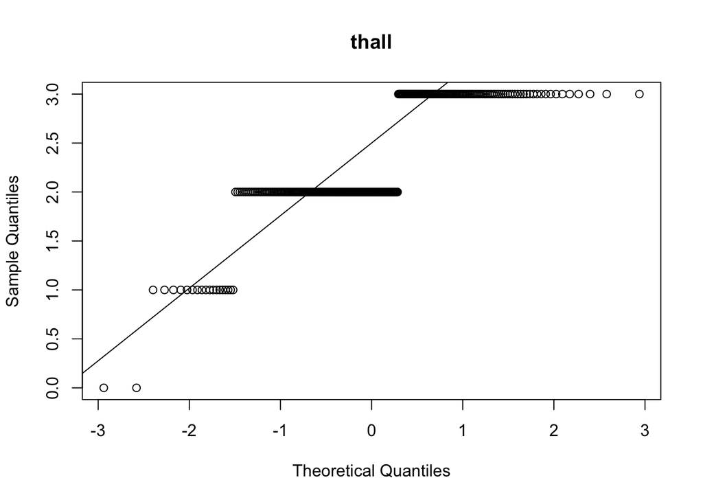

```r
var_names <- names(df)[1:14]
var_num <- var_names[sapply(df[var_names], is.numeric)]
for (i in var_num) {
  qqnorm(na.omit(df[[i]]), main = i)
  qqline(na.omit(df[[i]]))

}
```

Per a la comprovar la homogeneïtat de la variança:

```r
for (i in var_names) {
  if(is.numeric(df[[i]])){
    levene_test <- var.test(df[[i]] ~ df$output)
    print(paste(i, ": p-value = ", levene_test$p.value))
  }
}
```

```
## [1] "age : p-value =  0.0280731363393591"
## [1] "trtbps : p-value =  0.0714572799576749"
## [1] "chol : p-value =  0.33533240236138"
## [1] "thalachh : p-value =  0.0439333150911281"
## [1] "oldpeak : p-value =  5.9760818515997e-10"
## [1] "slp : p-value =  0.49875624806208"
## [1] "caa : p-value =  0.0114463984756439"
## [1] "thall : p-value =  2.5668326681938e-06"
```

Observant els valors de p-value, totes les variables que tenen un p-value superior a 0.05 tenen variàncies similars a la nostre variable d’estudi `output`.

### 4.3 Aplicació de proves estadístiques per comparar els grups de dades.

#### 4.3.1 Test d’hipòtesis

Hipòtesi alternativa (Ha): Hi ha una diferència significativa en la mitjana de “thalach” entre els pacients que tenen una major probabilitat de patir un atac de cor i els pacients que tenen una menor probabilitat.

Abans de fer una prova t per comparar les mitjanes de dos grups, és recomanable comprovar si les variàncies són iguals o diferents entre els dos grups. Això es coneix com la suposició d’igualtat de variàncies i és necessària per aplicar una prova t estandarditzada.

Com que el valor p obtingut a la prova d’abans, és menor que el nivell de significància (0.05), es rebutja la hipòtesi nul·la d’igualtat de variàncies i s’ha d’utilitzar una prova t no paramètrica com la prova de Welch.

```r
t.test(thalachh ~ output, data=df, var.equal=FALSE)
```

```
##
##  Welch Two Sample t-test
##
## data:  thalachh by output
## t = -7.953, df = 269.9, p-value = 5.019e-14
## alternative hypothesis: true difference in means between group Yes and group No is not equal to 0
## 95 percent confidence interval:
##  -24.15912 -14.57132
## sample estimates:
## mean in group Yes  mean in group No
##          139.1014          158.4667
```

La sortida de l’output de la prova t de Welch indica el següent:

- El valor t obtingut és -7.953, cosa que indica una diferència significativa entre les mitjanes de “thalach” per als dos grups (target=0 i target=1).
- El valor p és molt petit (5.019e-14), cosa que indica que la probabilitat d’obtenir un valor t tan extrem o més extrem sota la hipòtesi nul·la (sense diferència significativa) és molt petita. Per tant, es rebutja la hipòtesi nul·la.
- Els valors mitjans de la variable “thalach” per als dos grups són: 139.1014 per a target=0 i 158.4667 per a target=1.

#### 4.3.2 Correlació

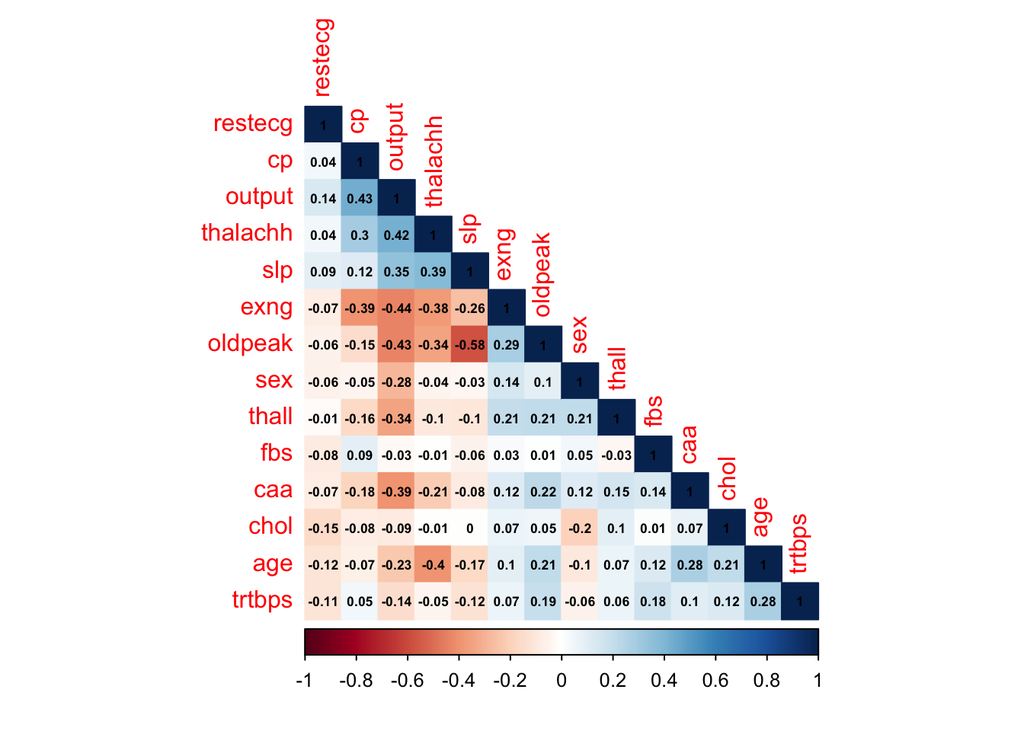

```r
if (!require('corrplot')) install.packages('corrplot'); library(corrplot)
cor <- cor(df2)

corrplot(cor,method = 'color',type = 'lower',
         order = 'hclust',cl.ratio = 0.2,
         addCoef.col = 'black',
         number.cex = 0.55)
```

#### 4.3.3 Classificació

A continuació provarem un model de GradientBoosting amb la llibreria Caret per tal de fer una primera aproximació de la variable `output` per tal de veure si amb aquest conjunt de dades podem predir de forma eficaç el risc coronari, i en cas que així sigui, quines son les variables més importants per el model.

```r
if (!require('caret')) install.packages('caret'); library(caret)
if (!require('gbm')) install.packages('gbm'); library(gbm)
set.seed(619)
indexes <- createDataPartition(df$output,p = 0.75,list = FALSE)
```

```r
trainData <-  df[indexes,]
testData <-  df[-indexes,]
```

```r
fitControl4 <-  trainControl(method = 'repeatedcv',
                             number=10,
                             repeats=1,
                             classProbs=TRUE,
                             summaryFunction = twoClassSummary)
```

```r
gbmGrid4 <-  expand.grid(interaction.depth = c(1:9),
                         n.trees = (1:30)*10,
                         shrinkage = 0.1,
                         n.minobsinnode = c(10,20,30,40,50))
```

```r
xgbe4 <-  train(output~.,
                data = df,
                method = 'gbm',
                verbose=FALSE,
                tuneGrid = gbmGrid4,
                trControl = fitControl4,
                metric='ROC')
```

```r
preds4 <-  predict(xgbe4, testData)
levels(preds4)=c("Yes","No")
confusionMatrix(preds4, testData$output)
```

```
## Confusion Matrix and Statistics
##
##           Reference
## Prediction Yes No
##        Yes  28  2
##        No    6 39
##
##                Accuracy : 0.8933
##                  95% CI : (0.8006, 0.9528)
##     No Information Rate : 0.5467
##     P-Value [Acc > NIR] : 9.35e-11
##
##                   Kappa : 0.7826
##
##  Mcnemar's Test P-Value : 0.2888
##
##             Sensitivity : 0.8235
##             Specificity : 0.9512
##          Pos Pred Value : 0.9333
##          Neg Pred Value : 0.8667
##              Prevalence : 0.4533
##          Detection Rate : 0.3733
##    Detection Prevalence : 0.4000
##       Balanced Accuracy : 0.8874
##
##        'Positive' Class : Yes
##
```

Tal i com indica la matriu de confusió. El model té una alta capacitat de discernir entre els valors positius i negatius de la variable `output`. És especialment bo, a l’hora d’encertar el nombre de negatius amb un valor per sobre de 95. Segurament la capacitat de ditingir entre veritables i falsos positius no sigui gaire bona tenint en compte el context del problema. En aquest cas seria distingir entre persones amb risc coronari o no.

```r
xgbe4$results[best(xgbe4$results, metric='ROC', maximize=TRUE),]
```

```
##     shrinkage interaction.depth n.minobsinnode n.trees       ROC      Sens
## 252       0.1                 2             40     120 0.9151665 0.7879121
##          Spec      ROCSD    SensSD    SpecSD
## 252 0.8533088 0.05520859 0.1530198 0.1203535
```

Segons el model entrenat ambc aret. En la millor parametrització del amteix s’arriba a un roc de 0.91. Mentre que en el següent gràfic realitzat amb la llibreria pROC el ROC és de 0.88. Un ROC especialment alt.

```r
if (!require('pROC')) install.packages('pROC'); library(pROC)
```

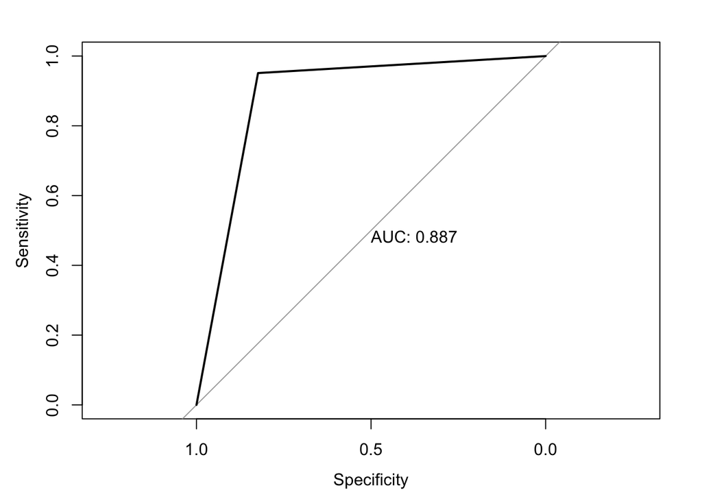

```r
roc <- roc(testData$output,as.numeric(preds4),plot=TRUE,print.auc=TRUE)
```

```r
featureImportance <-  varImp(xgbe4, scale=FALSE)
featureImportance
```

```
## gbm variable importance
##
##          Overall
## thall     39.117
## caa       37.083
## exng1     21.087
## thalachh  20.680
## oldpeak   19.328
## age       15.533
## slp       11.495
## chol      10.966
## cp2        8.673
## sex1       7.714
## trtbps     7.028
## restecg1   2.752
## fbs1       0.000
## restecg2   0.000
## cp1        0.000
## cp3        0.000
```

Finalment observem la importància de les variables que ha utilitzat el model. En aquest cas la variable `thalachh` és la quarta en ordre d’importància, per tant, si bé té una importància signifcativa, hi ha altres variables com `thall` -existència o no d’un trastorn sanguini- o `caa`-nombre de vasos principals, que tenen més importància que la freqüència cardíaca màxima d’una persona.

Investigació prèvia : Alexandre,Arnau  
Redacció de les respostes : Alexandre,Arnau  
Desenvolupament del codi: Alexandre,Arnau  
Participació al video: Alexandre,Arnau

Link github: https://github.com/PandaPandula/PRACTICA2TCVD Link video: https://drive.google.com/file/d/1__YF6e_OVsVKE2Zr6Ux8QHB8MsayjhvQ/view?usp=share_link